# 第9講 記述統計量

## 分位点と最頻値の計算

### 問題

東京の気候データ (`tokyo_weather.csv`) の中の

- 気温 (`temp`; 数値データ)
- 最多風向 (`wdir`; ラベルデータ)

を用いて 以下の問に答えよ．

- 全てのデータを用いて気温の四分位点を求めよ．(データ数365)
- 5の付く日(各月の5,15,25)の気温の四分位点を求めよ．(データ数36)
- ランダムに選んだ36日分のデータで気温の四分位点がどのくらいばらつくか確認せよ．
- 風向の最頻値を求めよ．

### 解答欄

### 解答例

気温の分位点を求める． 関数 `base::summary()` を利用する場合は以下のようになる．

```r
(tw_temp_summary <-
     tw_data |>
     pull(temp) |> # 1列のみ抽出してベクトルにする
     summary())
```

```
   Min. 1st Qu.  Median    Mean 3rd Qu.    Max.
   2.40    9.30   17.30   17.37   26.30   32.30
```

データの部分集合による計算(例えば5の付く日のデータ)は以下のようにすればよい．

```r
tw_data |>
    filter(day %in% c(5,15,25)) |>
    pull(temp) |>
    summary()
```

```
   Min. 1st Qu.  Median    Mean 3rd Qu.    Max.
  4.100   9.425  17.600  17.192  24.750  32.100
```

ランダムに選択した36日で推定した場合のばらつきを調べる．

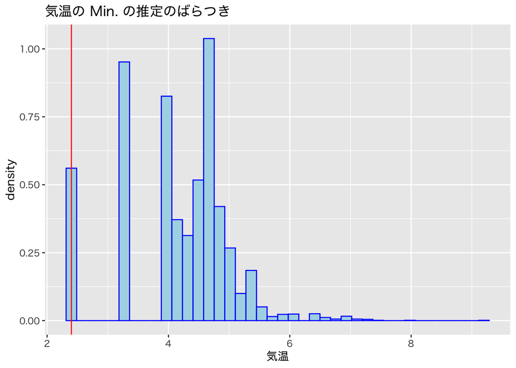

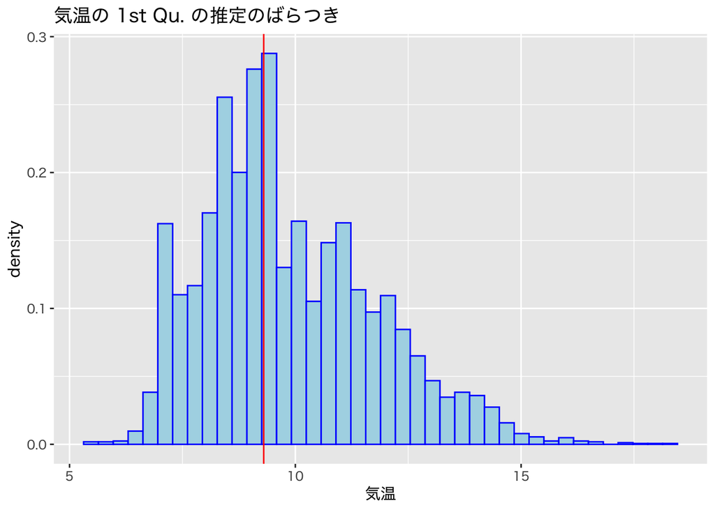

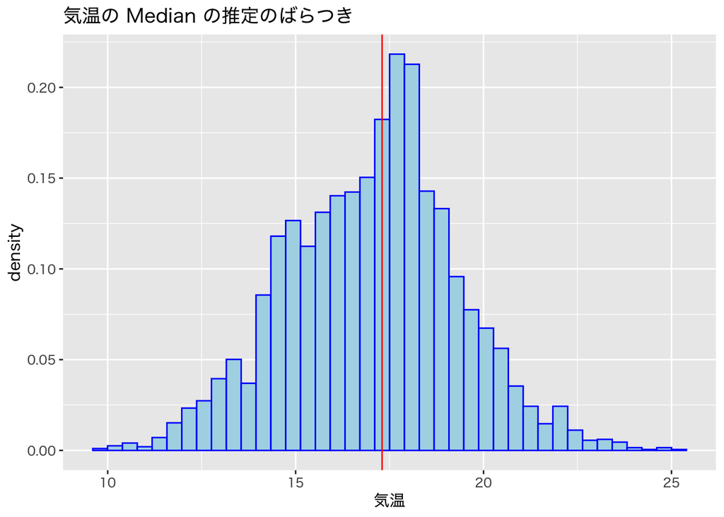

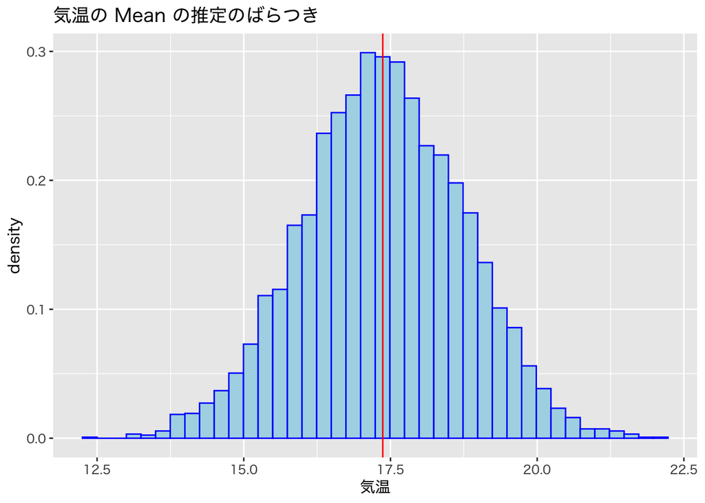

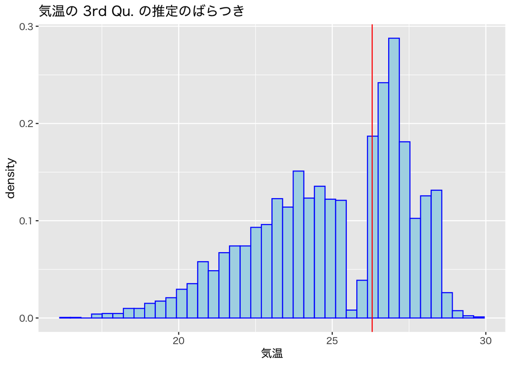

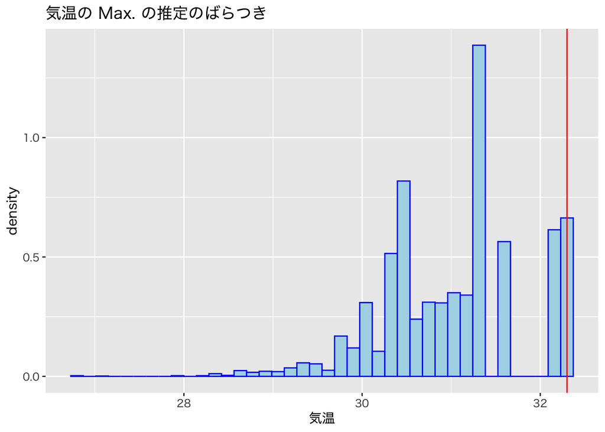

```r
mc <- 5000 # 実験回数を指定
my_trial <- function(){
    tw_data |>
        slice(sample(nrow(tw_data),36)) |> # 重複なしで36行選ぶ
        pull(temp) |>
        summary()
}
my_data <-
    replicate(mc, my_trial()) |> t() |> as_tibble()
#' ヒストグラムの表示
for(name in names(my_data)){
    gg <- my_data |>
        ggplot(aes(x = !!sym(name))) +
        geom_histogram(aes(y = after_stat(density)),
                       bins = 40,
                       fill = "lightblue",
                       colour = "blue") +
        geom_vline(xintercept = tw_temp_summary[[name]],
                   colour = "red") +
        labs(x = "気温",
             title = paste("気温の", name, "の推定のばらつき"))
    print(gg)
}
```

以下のようにすれば定義域とビンを揃えて表示することができる．

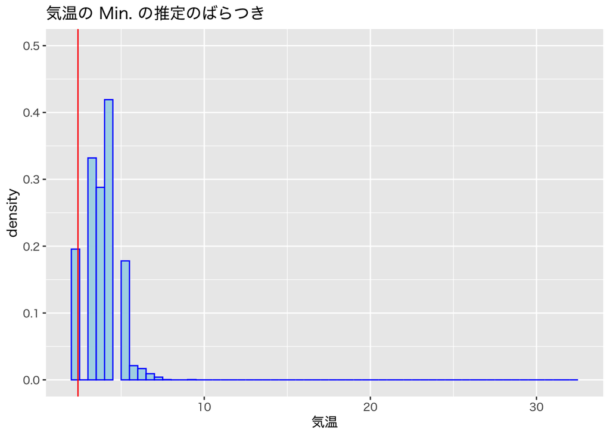

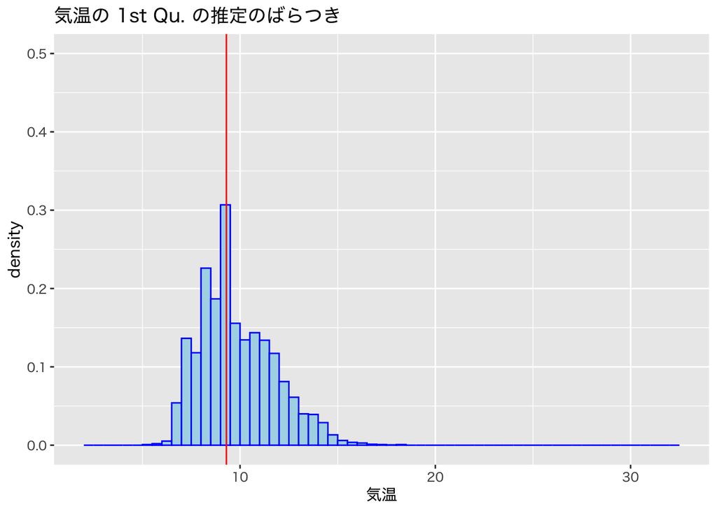

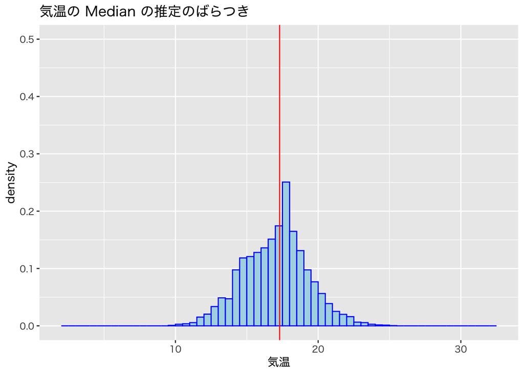

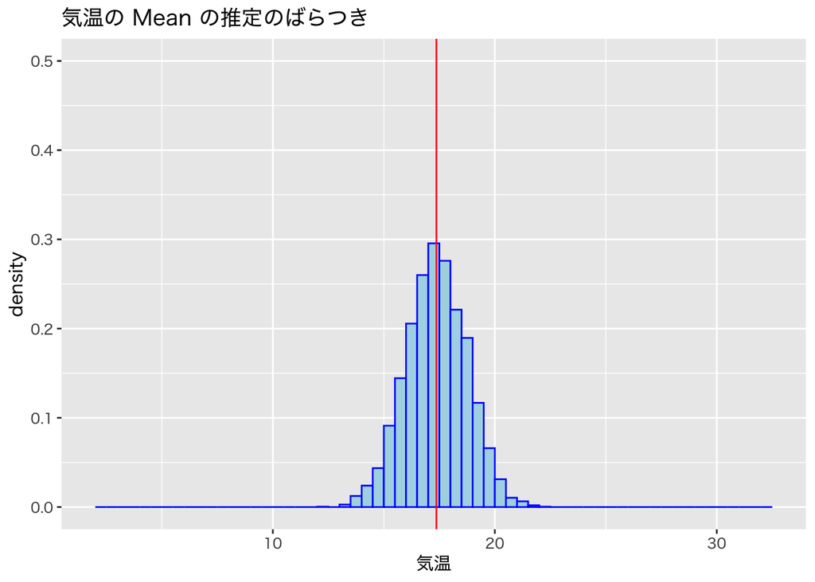

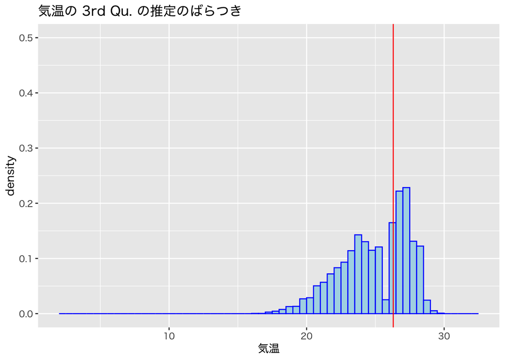

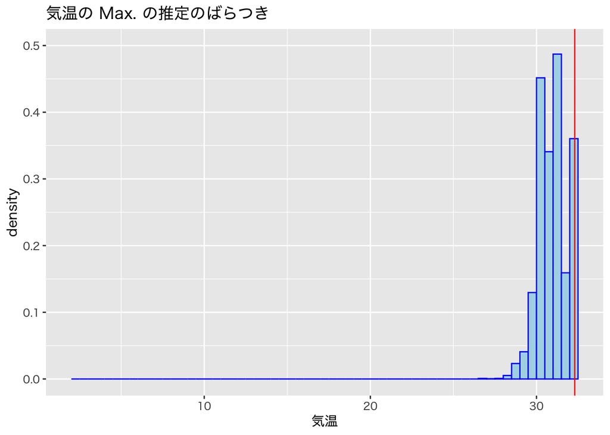

```r
breaks <-          # 全データを用いて適切なビンを計算して固定する
    tw_data |>
    pull(temp) |>
    pretty(n = 50) # データの値域を50程度の切りの良い数字に分割
for(name in names(my_data)){
    gg <- my_data |>
        ggplot(aes(x = !!sym(name))) +
        geom_histogram(aes(y = after_stat(density)),
                       breaks = breaks, # ビンを指定
                       fill = "lightblue",
                       colour = "blue") +
        geom_vline(xintercept = tw_temp_summary[[name]],
                   colour = "red") +
        ylim(0,0.5) + # y軸の表示を適当に固定する
        labs(x = "気温",
             title = paste("気温の", name, "の推定のばらつき"))
    print(gg)
}
```

表示には密度推定を用いても良い．

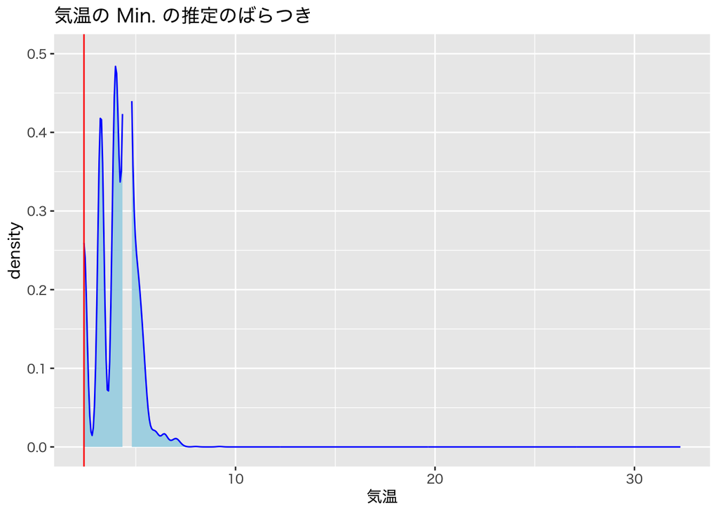

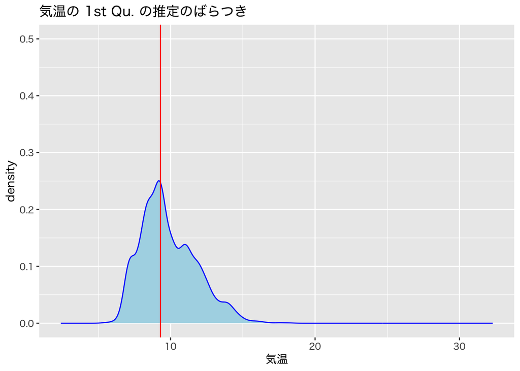

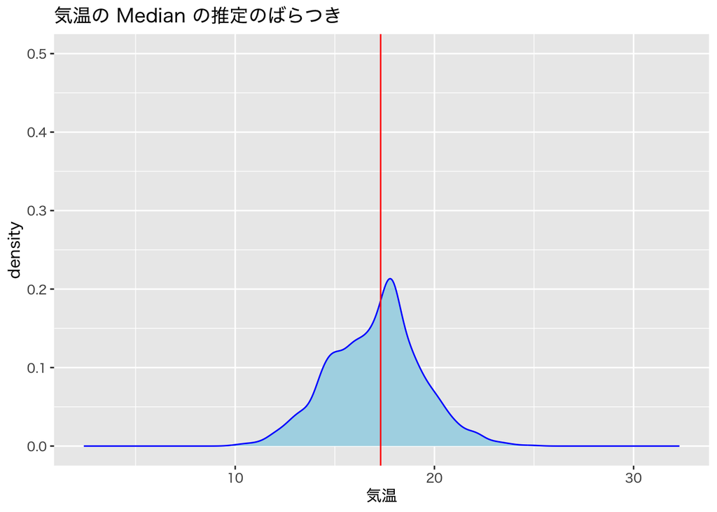

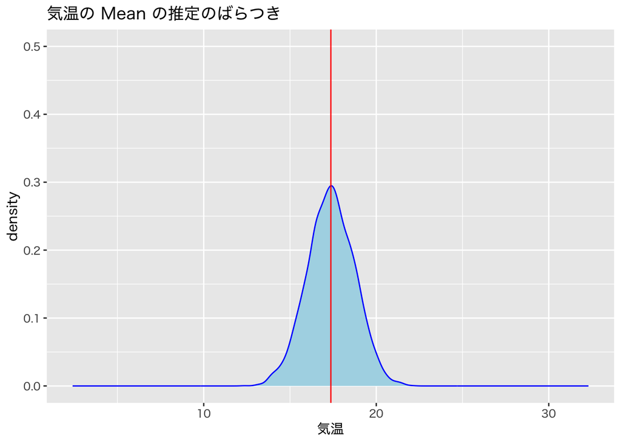

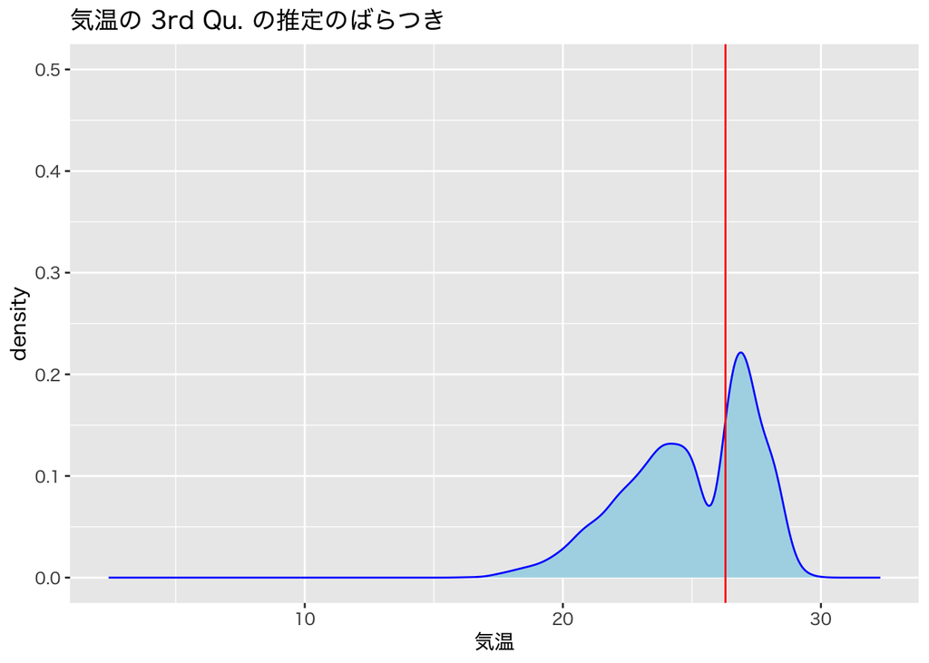

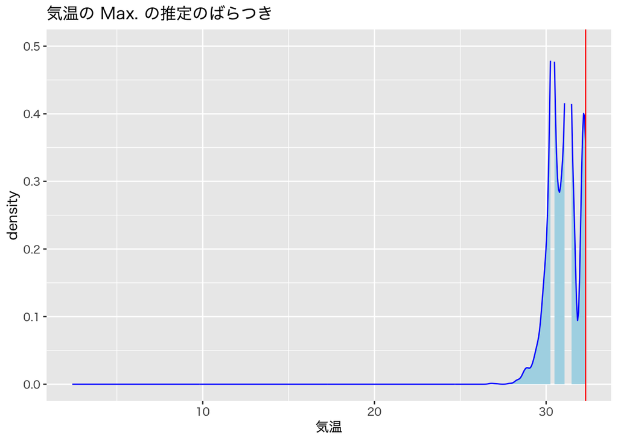

```r
for(name in names(my_data)){
    gg <- my_data |>
        ggplot(aes(x = !!sym(name))) +
        geom_density(fill = "lightblue",
                     colour = "blue") +
        geom_vline(xintercept = tw_temp_summary[[name]],
                   colour = "red") +
        lims(x = range(tw_data |> pull(temp)), y = c(0,0.5)) + # 表示範囲を指定
        labs(x = "気温",
             title = paste("気温の", name, "の推定のばらつき"))
    print(gg)
}
```

最多風向の最頻値を調べる．

```r
tw_data |>
    count(wdir) # 頻度表を作成する
```

```
# A tibble: 14 × 2
   wdir      n
   <chr> <int>
 1 E         2
 2 ENE       6
 3 N        21
 4 NE       20
 5 NNE      21
 6 NNW      40
 7 NW       75
 8 S        65
 9 SE       14
10 SSE      70
11 SSW      15
12 SW        4
13 W         1
14 WNW      11
```

```r
tw_data |>
    count(wdir) |>
    slice_max(n) # n列が最大となる行を抽出する
```

```
# A tibble: 1 × 2
  wdir      n
  <chr> <int>
1 NW       75
```

```r
tw_data |>       # filterを用いることもできる
    count(wdir) |>
    filter(n == max(n))
```

```
# A tibble: 1 × 2
  wdir      n
  <chr> <int>
1 NW       75
```

例えば以下のようにすれば16方位の頻度をグラフ化することができる．

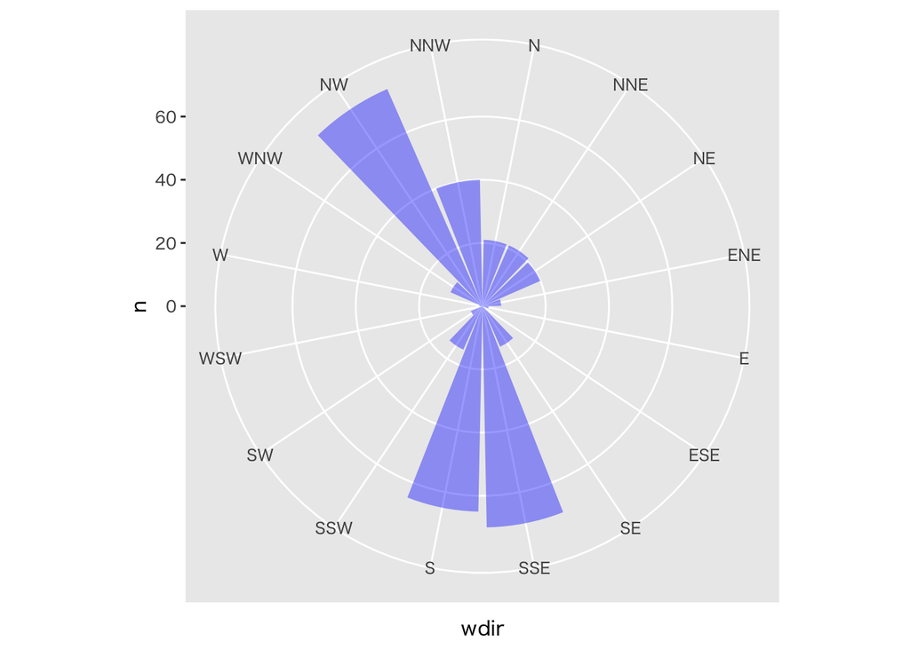

```r
#' 方向順に並べた文字列のベクトルを用意する
wdir_levels <- c("N","NNE","NE","ENE",
                 "E","ESE","SE","SSE",
                 "S","SSW","SW","WSW",
                 "W","WNW","NW","NNW")
tw_data |>
    mutate(wdir = factor(wdir, levels = wdir_levels)) |>
    count(wdir, .drop = FALSE) |> # 0も含めて16方位全て計算する
    ggplot(aes(x = wdir, y = n)) +
    geom_bar(stat = "identity", fill = alpha("blue", 0.4)) +
    coord_polar(start = 0) # 極座標表示にする
```

中心を空洞にするには負の値で下駄を履かせればよい．

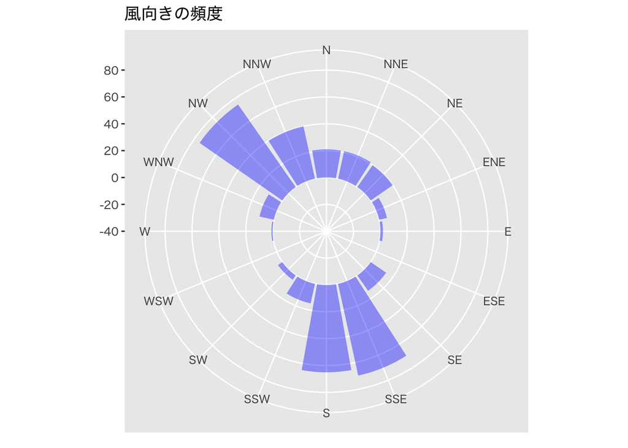

```r
tw_data |>
    mutate(wdir = factor(wdir, levels = wdir_levels)) |>
    count(wdir, .drop = FALSE) |>
    ggplot(aes(x = wdir, y = n)) +
    geom_bar(stat = "identity", fill = alpha("blue", 0.4)) +
    ylim(-40,80) + # 負の側を表示範囲に加える
    coord_polar(start = -pi/16) + # 北を真上に配置
    labs(x = NULL, y = NULL, title = "風向きの頻度") # 不要なラベルを削除
```